# Project2

Rashmi Kadam, Dionte Watie 7/6/2021

- Introduction
- Linear Regresion Model
- Fitting Random forest model
- Fitted Boosted Tree Model

### Introduction

For this study we will be aiming to predict the number of bike users. The bike users have been split into two groups that will be the target variables (response), casual bikers that rent bikes casually and registered bikers that rent bikes regularly. The predictor variables that will be in question are:

- weekday (day of the week)
- season
- yr (year)
- holiday (whether it is a holiday or not)
- weathersit (weather: rainy, snowy, clear, cloudy)
- mnth
- atemp (Feeling temperature)
- windspeed

```r
library(tidyverse)
library(corrplot)
library(ggplot2)
library(ggpubr)
library(caret)
library(randomForest)
```

```r
set.seed(1)

# read Bike data
bikeData <- read_csv("day.csv")
```

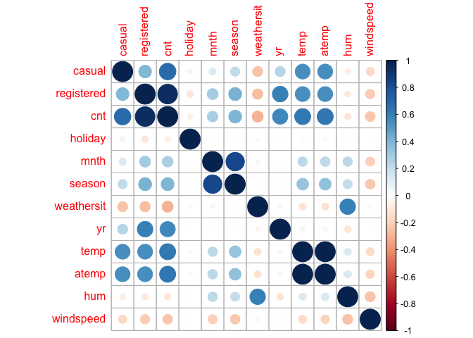

```r
# filtering weekday data
bikeDataWD <- bikeData %>% filter(weekday == weekday)

# Correlation graph has been used to select the predictors
Correlation <- cor(select(bikeDataWD, casual, registered, cnt,holiday, mnth, season,  weathersit ,yr, temp, atemp, hum, windspeed))

corrplot(Correlation)
```

```r
#Selected the predictors and factored the categorical predictors.

bikeDataM <- bikeDataWD %>% select (season, holiday, mnth, weathersit, atemp, windspeed, casual, registered, cnt, yr)

#
bikeDataM$mnth <- as.factor(bikeDataM$mnth)

bikeDataM$season <- factor(bikeDataM$season,
                          levels = c("1", "2","3","4") ,
                          labels = c("Spring","Summer","Fall","Winter"))

bikeDataM$holiday <- factor(bikeDataM$holiday,
                           levels = c("0", "1") ,
                           labels = c("Working Day","Holiday"))


bikeDataM$weathersit <- factor(bikeDataM$weathersit,
                          levels = c("1", "2","3","4") ,
                          labels = c("Good:Clear/Sunny","Moderate:Cloudy/Mist","Bad: Rain/Snow/Fog",
                                     "Worse: Heavy Rain/Snow/Fog"))

bikeDataM$yr <- factor(bikeDataM$yr,
                      levels = c("0", "1") ,
                      labels = c("2011","2012"))
```

Created train and test data sets

```r
train <- sample(1:nrow(bikeDataM), size = nrow(bikeDataM)*0.7)
test <- dplyr::setdiff(1:nrow(bikeDataM), train)
bikeDataTrain <- bikeDataM[train, ]
bikeDataTest <- bikeDataM[test, ]


summary(bikeDataTrain)
```

```
##     season           holiday         mnth                          weathersit      atemp           windspeed           casual
##  Spring:129   Working Day:498   5      : 50   Good:Clear/Sunny          :335   Min.   :0.07907   Min.   :0.02239   Min.   :   9.0
##  Summer:135   Holiday    : 13   10     : 45   Moderate:Cloudy/Mist      :165   1st Qu.:0.34026   1st Qu.:0.13682   1st Qu.: 332.0
##  Fall  :129                     1      : 44   Bad: Rain/Snow/Fog        : 11   Median :0.48673   Median :0.17787   Median : 742.0
##  Winter:118                     8      : 44   Worse: Heavy Rain/Snow/Fog:  0   Mean   :0.47411   Mean   :0.18886   Mean   : 867.2
##                                 2      : 43                                    3rd Qu.:0.60638   3rd Qu.:0.22886   3rd Qu.:1109.0
##                                 3      : 43                                    Max.   :0.84090   Max.   :0.44156   Max.   :3252.0
##                                 (Other):242
##    registered        cnt          yr
##  Min.   : 416   Min.   : 431   2011:243
##  1st Qu.:2689   1st Qu.:3332   2012:268
##  Median :3725   Median :4586
##  Mean   :3733   Mean   :4600
##  3rd Qu.:4924   3rd Qu.:6106
##  Max.   :6917   Max.   :8714
##
```

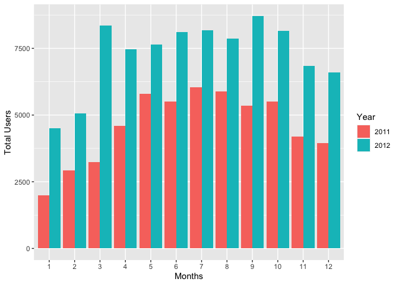

```r
#Side by side bar plots for month and count by year

Year <- bikeDataTrain$yr

ggplot(bikeDataTrain, aes(fill=Year, y=cnt, x=mnth)) +
    geom_bar(position="dodge", stat="identity") + xlab("Months") + ylab('Total Users')
```

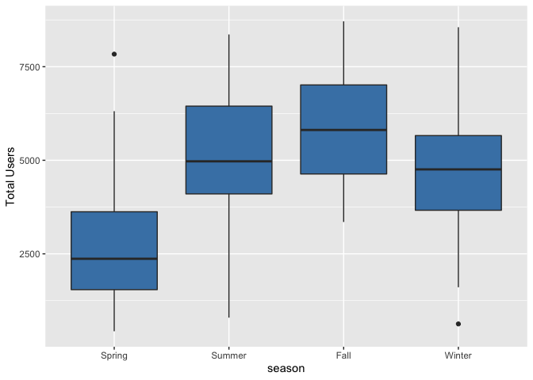

```r
#Boxplot of season versus count

ggplot(bikeDataTrain, aes(x = season,y=cnt)) +
  geom_boxplot(fill="steelblue") +ylab('Total Users')
```

```r
#Scatter plots for casual and registered versus actual temperature

mintemp <- -16
maxtemp <- 50

bikeDataTrain$atemp = bikeDataTrain$atemp * (maxtemp - mintemp) + mintemp
bikeDataTrain$atemp
```

[output not shown]

[output cut: 28 more lines]

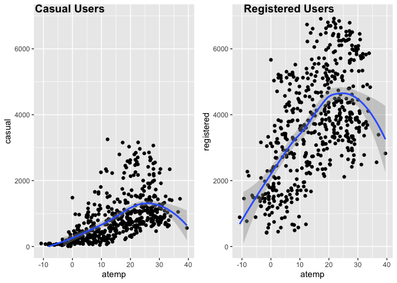

```r
  cTemp <- ggplot(bikeDataTrain,aes(x=atemp, y=casual)) + geom_point() + geom_smooth() + ylim(0, 7000)
  rTemp <- ggplot(bikeDataTrain, aes(x=atemp, y=registered)) + geom_point() + geom_smooth() + ylim(0, 7000)

  ggarrange(cTemp, rTemp, labels = c("Casual Users", "Registered Users"), ncol = 2, nrow = 1)
```

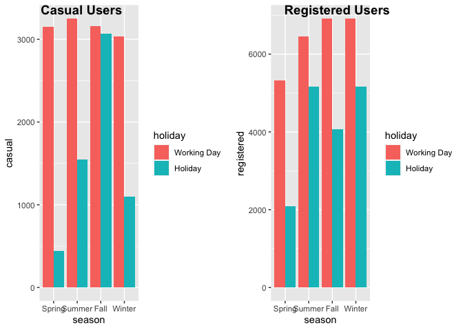

```r
#Dionte -- bar plots split by casual and registered users for season and holiday
rSeason <- ggplot(bikeDataTrain, aes(fill = holiday, x = season,y = registered,)) + geom_bar(position= 'dodge',stat = 'identity')

cSeason <- ggplot(bikeDataTrain, aes(fill = holiday, x = season,y = casual,)) + geom_bar(position= 'dodge',stat = 'identity')

ggarrange(cSeason, rSeason, labels= c("Casual Users", "Registered Users"), ncol = 2, nrow = 1)
```

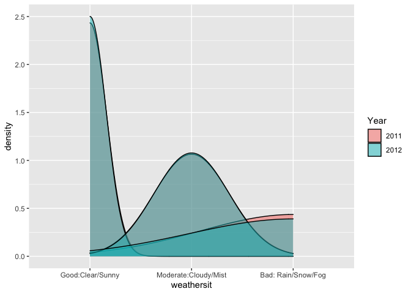

```r
#Dionte -- Density plot for weathersit by year
weather <- ggplot(bikeDataTrain, aes(x= weathersit))
weather + geom_density(adjust= 0.5, alpha= 0.5, aes(fill= Year), kernel="gaussian")
```

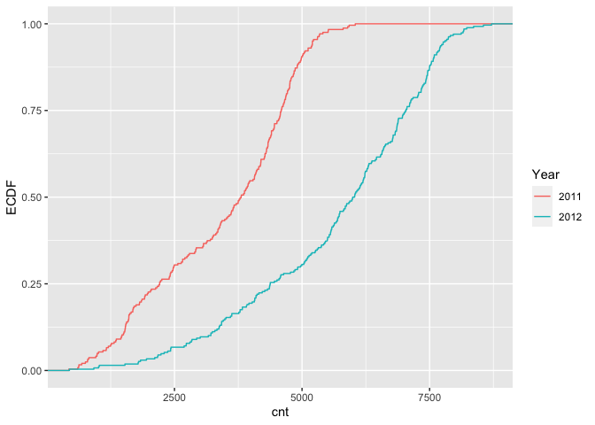

```r
#Dionte -- ECDF plot for count by year
cntPlot <- ggplot(bikeDataTrain, aes(x= cnt))
cntPlot + stat_ecdf(geom = 'step', aes(color= Year)) + ylab("ECDF")
```

```r
#Summary Statistics by Dionte
#variance, stdev, mean, and median of casual users by month
statsCasual <- bikeDataTrain %>%
  group_by(mnth) %>%
  summarise(avg = mean(casual),
            med = median(casual),
            var = var(casual),
            stDev = sd(casual))
statsCasual
```

```
## # A tibble: 12 x 5
##    mnth    avg   med     var stDev
##    <fct> <dbl> <dbl>   <dbl> <dbl>
##  1 1      183.  126.  25658.  160.
##  2 2      247.  206   32105.  179.
##  3 3      787.  762  363257.  603.
##  4 4     1051.  846  612873.  783.
##  5 5     1134.  887  417606.  646.
##  6 6     1374. 1071  514510.  717.
##  7 7     1269. 1038  377437.  614.
##  8 8     1195. 1174. 224307.  474.
##  9 9     1250. 1045  568687.  754.
## 10 10     917.  753  417704.  646.
## 11 11     641.  458. 239109.  489.
## 12 12     365.  329   51272.  226.
```

```r
#variance, stdev, mean, and median of registered users by month
statsRegistered <- bikeDataTrain %>%
  group_by(mnth) %>%
  summarise(avg = mean(registered),
            med = median(registered),
            var = var(registered),
            stDev = sd(registered))
statsRegistered
```

```
## # A tibble: 12 x 5
##    mnth    avg   med      var stDev
##    <fct> <dbl> <dbl>    <dbl> <dbl>
##  1 1     2084. 1822. 1185060. 1089.
##  2 2     2456. 2071  1211587. 1101.
##  3 3     3269. 3150  2630101. 1622.
##  4 4     3502. 3605  1941789. 1393.
##  5 5     4165. 3932. 1213507. 1102.
##  6 6     4688. 4488  1137650. 1067.
##  7 7     4503. 4278. 1508967. 1228.
##  8 8     4451. 4035  1557599. 1248.
##  9 9     4720. 4138  2213345. 1488.
## 10 10    4179. 3970  2469601. 1571.
## 11 11    3643. 3657  1715828. 1310.
## 12 12    3219. 3359  2745127. 1657.
```

```r
#variance, stdev, mean, and median of total bike users by season
statsCnt <- bikeDataTrain %>%
  group_by(season) %>%
  summarise(avg = mean(cnt),
            med = median(cnt),
            var = var(cnt),
            stDev = sd(cnt))
statsCnt
```

```
## # A tibble: 4 x 5
##   season   avg   med      var stDev
##   <fct>  <dbl> <dbl>    <dbl> <dbl>
## 1 Spring 2691. 2368  2178641. 1476.
## 2 Summer 5077. 4972  2902329. 1704.
## 3 Fall   5803. 5810  1847081. 1359.
## 4 Winter 4826. 4756. 2604519. 1614.
```

```r
#Calculating z statistic
tapply(bikeDataTrain$casual, INDEX = bikeDataTrain$weathersit, FUN = function(x){x -mean(x)/sd(x)})
```

[output not shown]

[output cut: 37 more lines]

```r
# summary statistics by Rashmi
#min max stdev and mean of feeling temperature by season
statsAtemp <- bikeDataTrain %>%
  group_by(season) %>%
  summarise(
    atemp.min = min(atemp),
    atemp.max = max(atemp),
    atemp.med = median(atemp),
    atemp.stdev = sd(atemp),
    atemp.mean = mean(atemp))
statsAtemp
```

```
## # A tibble: 4 x 6
##   season atemp.min atemp.max atemp.med atemp.stdev atemp.mean
##   <fct>      <dbl>     <dbl>     <dbl>       <dbl>      <dbl>
## 1 Spring -10.8          20.2      3.25        6.76       4.03
## 2 Summer   0.522        32.0     19.1         6.95      18.0
## 3 Fall    -0.00160      39.5     27.7         4.73      27.2
## 4 Winter  -0.958        24.1     11.5         6.16      11.5
```

```r
#min max stdev and mean of total bike users per year
statsYear<- bikeDataTrain %>%
  group_by(yr) %>%
  summarise(
    cnt.min = min(cnt),
    cnt.max = max(cnt),
    cnt.med = median(cnt),
    cnt.stdev = sd(cnt),
    cnt.mean = mean(cnt))
statsYear
```

```
## # A tibble: 2 x 6
##   yr    cnt.min cnt.max cnt.med cnt.stdev cnt.mean
##   <fct>   <dbl>   <dbl>   <dbl>     <dbl>    <dbl>
## 1 2011      431    6043   3805      1392.    3444.
## 2 2012      441    8714   6012.     1747.    5648.
```

```r
#min max stdev and mean of total bike users per holiday
statsHoliday<- bikeDataTrain %>%
  group_by(holiday) %>%
  summarise(
    cnt.min = min(cnt),
    cnt.max = max(cnt),
    cnt.med = median(cnt),
    cnt.stdev = sd(cnt),
    cnt.mean = mean(cnt))
statsHoliday
```

```
## # A tibble: 2 x 6
##   holiday     cnt.min cnt.max cnt.med cnt.stdev cnt.mean
##   <fct>         <dbl>   <dbl>   <dbl>     <dbl>    <dbl>
## 1 Working Day     431    8714    4605     1927.    4624.
## 2 Holiday        1013    6370    3351     1935.    3666.
```

```r
#contingency table

table(bikeDataTrain$holiday, bikeDataTrain$season)
```

```
##
##               Spring Summer Fall Winter
##   Working Day    125    132  126    115
##   Holiday          4      3    3      3
```

### Linear Regresion Model

Idea of linear regression model -Linear regression model assumes a linear relationship between the input variables (x) and the single output variable(y).The linear equation assigns one scale factor to each input value or column, called a coefficient and represented by the capital Greek letter Beta (B). It is a slope term.Regression models estimate the values of Beta. Betas are chosen by using ordianry least square method.Ordinary least squares minimize the sum of squared residuals assuming normality and constant variance on error terms.It is called linear regression because it is linear in parameters.

```r
#Fitting multiple regression models
set.seed(1)

bikeDataTrainF <- bikeDataTrain %>% select(cnt,season,weathersit,atemp,yr)
bikeDataTestF <- bikeDataTest %>% select(cnt,season,weathersit,atemp,yr)

lmRM<-lm(log(cnt)~.,data=bikeDataTrainF)
summary(lmRM)
```

```
##
## Call:
## lm(formula = log(cnt) ~ ., data = bikeDataTrainF)
##
## Residuals:
##      Min       1Q   Median       3Q      Max
## -1.34018 -0.09934  0.04008  0.13652  0.79585
##
## Coefficients:
##                                 Estimate Std. Error t value Pr(>|t|)
## (Intercept)                     7.444276   0.027004 275.675  < 2e-16 ***
## seasonSummer                    0.358872   0.038634   9.289  < 2e-16 ***
## seasonFall                      0.272637   0.050596   5.389 1.09e-07 ***
## seasonWinter                    0.529860   0.033774  15.689  < 2e-16 ***
## weathersitModerate:Cloudy/Mist -0.153734   0.023443  -6.558 1.36e-10 ***
## weathersitBad: Rain/Snow/Fog   -1.012419   0.075481 -13.413  < 2e-16 ***
## atemp                           0.025328   0.001751  14.463  < 2e-16 ***
## yr2012                          0.507062   0.021684  23.385  < 2e-16 ***
## ---
## Signif. codes:  0 '***' 0.001 '**' 0.01 '*' 0.05 '.' 0.1 ' ' 1
##
## Residual standard error: 0.2436 on 503 degrees of freedom
## Multiple R-squared:  0.8073, Adjusted R-squared:  0.8046
## F-statistic: 301.1 on 7 and 503 DF,  p-value: < 2.2e-16
```

```r
lmFit <- train(log(cnt) ~ ., data = bikeDataTrainF ,
         method = "lm",
         preProcess = c("center", "scale"),
         trControl = trainControl(method = "cv", number = 10))

predlm <- predict(lmFit, newdata = dplyr::select(bikeDataTestF,-cnt))

lmRM <- postResample(predlm, bikeDataTestF$cnt)

lmRMSE <- lmRM["RMSE"]

lmRMSE
```

```
##     RMSE
## 4690.809
```

```r
#Fitting Multiple Linear Regression model by Dionte
#Using BIC to select predictors for the best fit model
set.seed(1)

bic_selection = step(
  lm(cnt ~ 1, bikeDataTrain),
  scope = cnt ~ season + holiday + mnth + weathersit + atemp + windspeed + Year,
  direction = "both", k = log(nrow(bikeDataTrain))
)
```

```
## Start:  AIC=7737.71
## cnt ~ 1
##
##              Df Sum of Sq        RSS    AIC
## + atemp       1 786419172 1116120442 7471.4
## + season      3 693606350 1208933264 7524.7
## + Year        1 619282896 1283256717 7542.7
## + mnth       11 752082750 1150456864 7549.3
## + weathersit  2 204828941 1697710672 7692.0
## + windspeed   1  59099851 1843439762 7727.8
## <none>                    1902539613 7737.7
## + holiday     1  11625673 1890913940 7740.8
##
## Step:  AIC=7471.41
## cnt ~ atemp
##
##              Df Sum of Sq        RSS    AIC
## + Year        1 556098195  560022247 7125.2
## + weathersit  2  99528421 1016592021 7436.2
## + season      3 111126752 1004993690 7436.5
## <none>                    1116120442 7471.4
## + holiday     1   7634792 1108485650 7474.1
## + windspeed   1   7570900 1108549541 7474.2
## + mnth       11  88777658 1027342784 7497.7
## - atemp       1 786419172 1902539613 7737.7
##
## Step:  AIC=7125.25
## cnt ~ atemp + Year
##
##              Df Sum of Sq        RSS    AIC
## + season      3 131406606  428615641 7007.3
## + weathersit  2  81766554  478255693 7057.1
## + mnth       11 117921593  442100654 7073.0
## + windspeed   1  18631738  541390509 7114.2
## + holiday     1   8386637  551635610 7123.8
## <none>                     560022247 7125.2
## - Year        1 556098195 1116120442 7471.4
## - atemp       1 723234470 1283256717 7542.7
##
## Step:  AIC=7007.31
```

[output cut: 35 more lines]

```
## - season      3 148782886 467296807 7051.5
## - Year        1 556806329 875320251 7384.6
##
## Step:  AIC=6870.84
## cnt ~ atemp + Year + season + weathersit + holiday + windspeed
##
##              Df Sum of Sq       RSS    AIC
## <none>                    312522900 6870.8
## - windspeed   1   5991022 318513922 6874.3
## + mnth       11  33850413 278672487 6880.9
## - holiday     1  10266350 322789250 6881.1
## - weathersit  2 100785702 413308602 7001.2
## - atemp       1 122313049 434835948 7033.4
## - season      3 137216261 449739161 7038.1
## - Year        1 562092519 874615419 7390.5
```

```r
#Best fit linear regression model
bikeDataTrainF2 <- bikeDataTrain %>% select(cnt, atemp, season,weathersit)
bikeDataTestF2 <- bikeDataTest %>% select(cnt, atemp, season,weathersit)

bestLm <- lm(cnt ~ atemp + season + weathersit, data = bikeDataTrain)
bestLm
```

```
##
## Call:
## lm(formula = cnt ~ atemp + season + weathersit, data = bikeDataTrain)
##
## Coefficients:
##                    (Intercept)                           atemp                    seasonSummer                      seasonFall
##                        2625.41                           95.99                          998.55                          724.58
##                   seasonWinter  weathersitModerate:Cloudy/Mist    weathersitBad: Rain/Snow/Fog
##                        1485.06                         -689.26                        -2801.75
```

```r
summary(bestLm)
```

```
##
## Call:
## lm(formula = cnt ~ atemp + season + weathersit, data = bikeDataTrain)
##
## Residuals:
##     Min      1Q  Median      3Q     Max
## -3754.4 -1045.2  -140.5  1112.3  4236.1
##
## Coefficients:
##                                 Estimate Std. Error t value Pr(>|t|)
## (Intercept)                     2625.413    133.636  19.646  < 2e-16 ***
## atemp                             95.986      9.495  10.109  < 2e-16 ***
## seasonSummer                     998.551    209.814   4.759 2.54e-06 ***
## seasonFall                       724.583    274.542   2.639  0.00857 **
## seasonWinter                    1485.060    183.526   8.092 4.43e-15 ***
## weathersitModerate:Cloudy/Mist  -689.256    127.514  -5.405 1.00e-07 ***
## weathersitBad: Rain/Snow/Fog   -2801.745    410.166  -6.831 2.44e-11 ***
## ---
## Signif. codes:  0 '***' 0.001 '**' 0.01 '*' 0.05 '.' 0.1 ' ' 1
##
## Residual standard error: 1325 on 504 degrees of freedom
## Multiple R-squared:  0.5347, Adjusted R-squared:  0.5291
## F-statistic: 96.52 on 6 and 504 DF,  p-value: < 2.2e-16
```

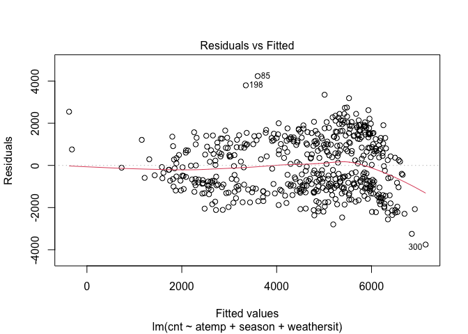

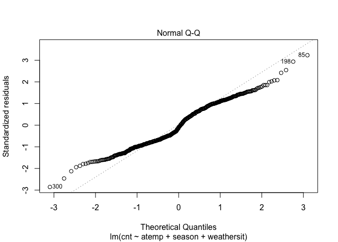

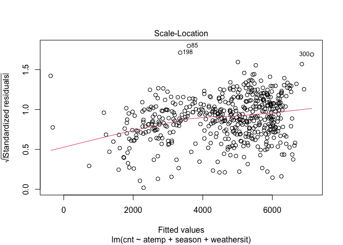

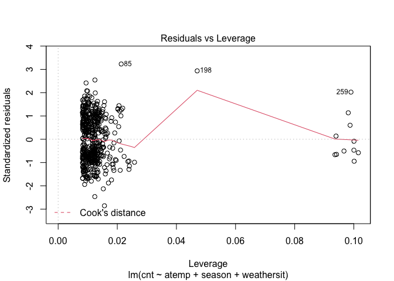

```r
plot(bestLm)
```

```r
bestLmFit <- train(cnt~ atemp + season +weathersit, data= bikeDataTrainF2,
                   method = "lm",
                   preProcess = c("center", "scale"),
                   trControl = trainControl(method = "cv", number = 10))
lmFitPred <- predict(bestLmFit, newdata = dplyr::select(bikeDataTestF2,-cnt))

lm2RM <- postResample(lmFitPred, bikeDataTestF2$cnt)

lm2RMSE <- lm2RM["RMSE"]

lm2RMSE
```

```
##     RMSE
## 2048.494
```

### Fitting Random forest model

Random Forest model is tree based method used to prediction. It is powerful ensembling machine learning algorithm which extends the idea of bagging but instead of including every predictor, we are including subset of predictors. It works by creating bootstrap samples fitting a tree for each bootstrap sample. Random Forest method avoids correlation amoung the trees. It uses m subset of predictors.

m = SQRT(p) for classification and m = p/3 for regression.

```r
set.seed(1)


rfFit <- train(cnt ~ .,
               method = "rf",
               trControl = trainControl(method = "repeatedcv",
                                        repeats = 3,
                                        number = 10),
               tuneGrid = data.frame(mtry = 1:9),
               data = bikeDataTrainF)
rfFit
```

```
## Random Forest
##
## 511 samples
##   4 predictor
##
## No pre-processing
## Resampling: Cross-Validated (10 fold, repeated 3 times)
## Summary of sample sizes: 462, 460, 459, 459, 459, 460, ...
## Resampling results across tuning parameters:
##
##   mtry  RMSE       Rsquared   MAE
##   1     1382.9084  0.8186542  1127.8056
##   2      907.9500  0.8462932   715.2261
##   3      769.2386  0.8535410   577.1478
##   4      758.1923  0.8504646   554.6221
##   5      776.1777  0.8421840   559.4482
##   6      797.6310  0.8332374   570.4070
##   7      815.6697  0.8258733   581.9745
##   8      827.9276  0.8208881   591.9999
##   9      826.5625  0.8215303   591.8686
##
## RMSE was used to select the optimal model using the smallest value.
## The final value used for the model was mtry = 4.
```

```r
rfPred <- predict(rfFit,  newdata = dplyr::select(bikeDataTestF,-cnt))
rfRM <- postResample(rfPred, bikeDataTestF$cnt)
rfRMSE <- rfRM["RMSE"]

rfRMSE
```

```
##     RMSE
## 1879.672
```

### Fitted Boosted Tree Model

```r
set.seed(1)

trCtrl <- trainControl(method = "repeatedcv", number = 10, repeats =3)
set.seed(1)
BoostFit <- train(cnt ~., data = bikeDataTrain,
                     method = "gbm",
                      verbose = FALSE,
                     preProcess = c("center", "scale"),
                     trControl = trCtrl)
BoostFit
```

```
## Stochastic Gradient Boosting
##
## 511 samples
##   9 predictor
##
## Pre-processing: centered (23), scaled (23)
## Resampling: Cross-Validated (10 fold, repeated 3 times)
## Summary of sample sizes: 462, 460, 459, 459, 459, 460, ...
## Resampling results across tuning parameters:
##
##   interaction.depth  n.trees  RMSE      Rsquared   MAE
##   1                   50      346.0292  0.9785046  256.89920
##   1                  100      195.7301  0.9901757  148.93090
##   1                  150      170.1433  0.9924695  130.35911
##   2                   50      202.5861  0.9906071  152.50837
##   2                  100      142.4120  0.9947982  109.33621
##   2                  150      123.2981  0.9961000   94.03800
##   3                   50      173.2665  0.9925198  125.95320
##   3                  100      132.7285  0.9953756   97.44595
##   3                  150      122.3468  0.9960606   89.07694
##
## Tuning parameter 'shrinkage' was held constant at a value of 0.1
## Tuning
##  parameter 'n.minobsinnode' was held constant at a value of 10
## RMSE was used to select the optimal model using the smallest value.
## The final values used for the model were n.trees = 150, interaction.depth = 3, shrinkage =
##  0.1 and n.minobsinnode = 10.
```

```r
BoostFitPred <- predict(BoostFit, newdata = dplyr::select(bikeDataTest, -cnt))
BoostFitPred
```

[output not shown]

```r
bfRM <- postResample(BoostFitPred, bikeDataTest$cnt)

bfRMSE <- bfRM["RMSE"]
bfRMSE
```

```
##     RMSE
## 117.9052
```

```r
cRMSEsTitles <- c("Linear Regression Model","Liner Regression Model 2","Random Forest","Boosted Tree")

cRMSEs <- c(lm = lmRMSE, lm2 = lm2RMSE, rf = rfRMSE, boost = bfRMSE)
cRMSEs
```

```
##    lm.RMSE   lm2.RMSE    rf.RMSE boost.RMSE
##  4690.8094  2048.4940  1879.6715   117.9052
```

```r
bestCRMSE <- cRMSEsTitles[which.min(cRMSEs)]

bestCRMSE
```

```
## [1] "Boosted Tree"
```

*Best model fit is :Boosted Tree model*